# Jefferson Region: Distributions and Proportions

Julia Meinhardt

9/15/2020

```r
knitr::opts_chunk$set(echo = TRUE)
```

```r
library(ggplot2)
library(tidyverse)
library(ggthemes)
library(dplyr)
```

```r
Jefferson_tract_data <- read_csv("jeffersonbay2018.csv") %>%
  filter(region == "Jefferson")
attach(Jefferson_tract_data)
```

## Description and Variable List

This document will explore summary statistics of the following variables:

**List of Variables**

1. Total Population: total_popE = (continuous)
2. Total below 150 % poverty level: low_income (continuous)
3. Percent of population receiving public assistance (including SSI): (continuous)
4. Percent of population receiving cash public assistance (including food stamps/SNAP): (continuous)
5. High School Graduates: (categorical, >83% meets statewide average)
6. Some college or Associates: (categorical, >29% meets statewide average)
7. Bachelors or higher: (categorical, >33% meets statewide average)
8. County (categorical)
9. Region (categorical)

All calculations are for the Jefferson Region of my dataset. The Bay Region calculations and distributions are done in a separate file.

## Summary Stats and Visualizations

### Population Summary Stats

**Population is measured as the number of people per tract.**

```r
summary(total_popE)
```

```
##    Min. 1st Qu.  Median    Mean 3rd Qu.    Max.
##     584    2189    3288    3423    4345    9353
```

```r
sd(total_popE)
```

```
## [1] 1633.146
```

```r
pop_mean1 <- t.test(total_popE)
pop_mean1
```

```
##
##  One Sample t-test
##
## data:  total_popE
## t = 20.319, df = 93, p-value < 2.2e-16
## alternative hypothesis: true mean is not equal to 0
## 95 percent confidence interval:
##  3088.191 3757.192
## sample estimates:
## mean of x
##  3422.691
```

```r
hist1 <- ggplot(Jefferson_tract_data, aes(x = total_popE)) +
  geom_histogram()
```

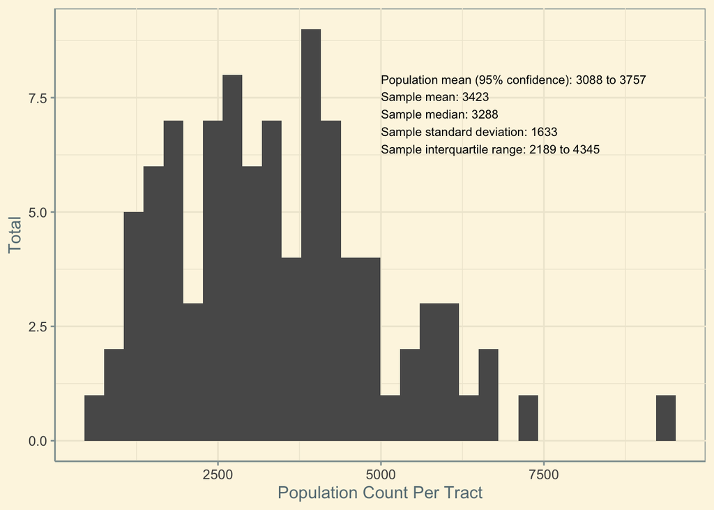

```r
hist1+
  theme_solarized() +
  scale_x_continuous(name = "Population Count Per Tract") +
  scale_y_continuous(name = "Total") +
  annotate("text", x = 5000, y = 8, size = 3,
           label = paste("Population mean (95% confidence):",
                         prettyNum(pop_mean1$conf.int[1], digits = 0),
                         "to",
                         prettyNum(pop_mean1$conf.int[2], digits = 0),

                         "\nSample mean:",
                         prettyNum(mean(total_popE), digits = 0),
                         "\nSample median:",
                         prettyNum(median(total_popE), digits = 0),
                         "\nSample standard deviation:",
                         prettyNum(sd(total_popE), digits = 0),
                         "\nSample interquartile range:",
                         prettyNum(quantile(total_popE)["25%"], digits = 0),
                         "to",
                         prettyNum(quantile(total_popE)["75%"], digits = 0)),
           hjust = 0, vjust = 1)
```

The outlier population of over 9,000 here is a prison population in Lassen County.

### Low Income Summary Stats

**Low-income is measured as the percent of the population that is living below 150% poverty per tract.**

```r
summary(low_income)
```

```
##    Min. 1st Qu.  Median    Mean 3rd Qu.    Max.
## 0.02983 0.18781 0.26417 0.27015 0.34671 0.49956
```

```r
sd(low_income)
```

```
## [1] 0.1058637
```

```r
pop_mean3 <- t.test(low_income)
pop_mean3
```

```
##
##  One Sample t-test
##
## data:  low_income
## t = 24.742, df = 93, p-value < 2.2e-16
## alternative hypothesis: true mean is not equal to 0
## 95 percent confidence interval:
##  0.248471 0.291837
## sample estimates:
## mean of x
##  0.270154
```

```r
hist3<- ggplot(Jefferson_tract_data, aes(x = low_income)) +
  geom_histogram()
```

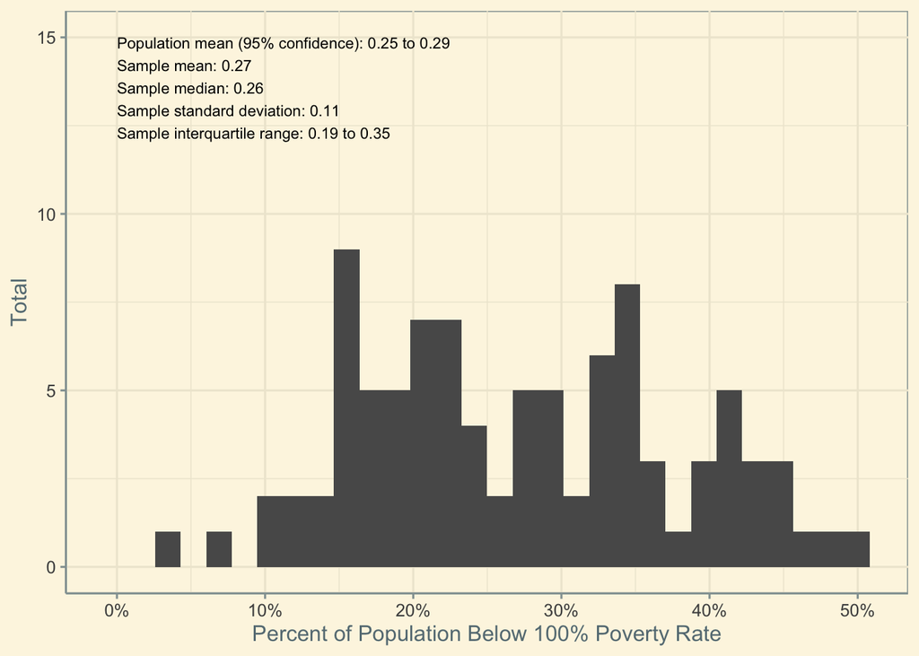

```r
hist3+
  theme_solarized() +
  scale_x_continuous(name = "Percent of Population Below 100% Poverty Rate",
                      breaks = seq(0.0, 0.6, by = 0.1),
                     labels = paste(seq(0, 60, by = 10), "%", sep = ""))+
  scale_y_continuous(name = "Total") +
  annotate("text", x = 0, y = 15, size = 3,
           label = paste("Population mean (95% confidence):",
                         prettyNum(pop_mean3$conf.int[1], digits = 2),
                         "to",
                         prettyNum(pop_mean3$conf.int[2], digits = 2),

                         "\nSample mean:",
                         prettyNum(mean(low_income), digits = 2),
                         "\nSample median:",
                         prettyNum(median(low_income), digits = 2),
                         "\nSample standard deviation:",
                         prettyNum(sd(low_income), digits = 2),
                         "\nSample interquartile range:",
                         prettyNum(quantile(low_income)["25%"], digits = 2),
                         "to",
                         prettyNum(quantile(low_income)["75%"], digits = 2)),
           hjust = 0, vjust = 1)
```

### Public Assistance Summary Stats and Distribution

**Public assistance is measured as the percent of the population receiving public assistance (including SSI) per tract.**

```r
summary(pub_assist)
```

```
##    Min. 1st Qu.  Median    Mean 3rd Qu.    Max.
##  0.0495  0.3796  0.4100  0.4074  0.4443  0.5090
```

```r
sd(pub_assist)
```

```
## [1] 0.06119938
```

```r
pop_mean6 <- t.test(pub_assist)
pop_mean6
```

```
##
##  One Sample t-test
##
## data:  pub_assist
## t = 64.543, df = 93, p-value < 2.2e-16
## alternative hypothesis: true mean is not equal to 0
## 95 percent confidence interval:
##  0.3948756 0.4199453
## sample estimates:
## mean of x
## 0.4074104
```

```r
hist6 <- ggplot(Jefferson_tract_data, aes(x = pub_assist)) +
  geom_histogram()
```

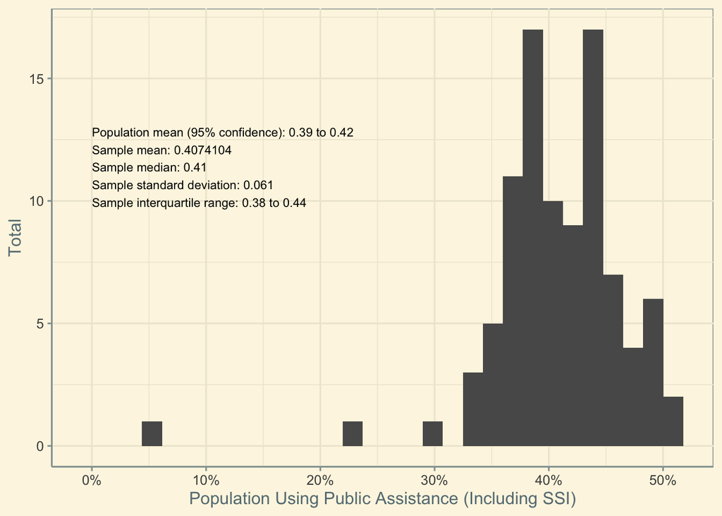

```r
hist6+
  theme_solarized() +
  scale_x_continuous(name = "Population Using Public Assistance (Including SSI)",
                     breaks = seq(0.0, 0.6, by = 0.1),
                     labels = paste(seq(0, 60, by = 10), "%", sep = "")) +
  scale_y_continuous(name = "Total") +
  annotate("text", x = 0, y = 13, size = 3,
           label = paste("Population mean (95% confidence):",
                         prettyNum(pop_mean6$conf.int[1], digits = 2),
                         "to",
                         prettyNum(pop_mean6$conf.int[2], digits = 2),

                         "\nSample mean:",
                         prettyNum(mean(pub_assist), digits = ),
                         "\nSample median:",
                         prettyNum(median(pub_assist), digits = 2),
                         "\nSample standard deviation:",
                         prettyNum(sd(pub_assist), digits = 2),
                         "\nSample interquartile range:",
                         prettyNum(quantile(pub_assist)["25%"], digits = 2),
                         "to",
                         prettyNum(quantile(pub_assist)["75%"], digits = 2)),
           hjust = 0, vjust = 1)
```

### Cash Assistance Summary Stats and Distribution

**Cash assistance is measured as the percent of the population receiving cash assistance (including food stamps) per tract.**

```r
summary(cash_assist)
```

```
##     Min.  1st Qu.   Median     Mean  3rd Qu.     Max.
## 0.003546 0.030379 0.045241 0.047878 0.061432 0.146428
```

```r
sd(cash_assist)
```

```
## [1] 0.02522873
```

```r
pop_mean7 <- t.test(cash_assist)
pop_mean7
```

```
##
##  One Sample t-test
##
## data:  cash_assist
## t = 18.399, df = 93, p-value < 2.2e-16
## alternative hypothesis: true mean is not equal to 0
## 95 percent confidence interval:
##  0.04271017 0.05304486
## sample estimates:
##  mean of x
## 0.04787752
```

```r
hist7 <- ggplot(Jefferson_tract_data, aes(x = cash_assist)) +
  geom_histogram()
```

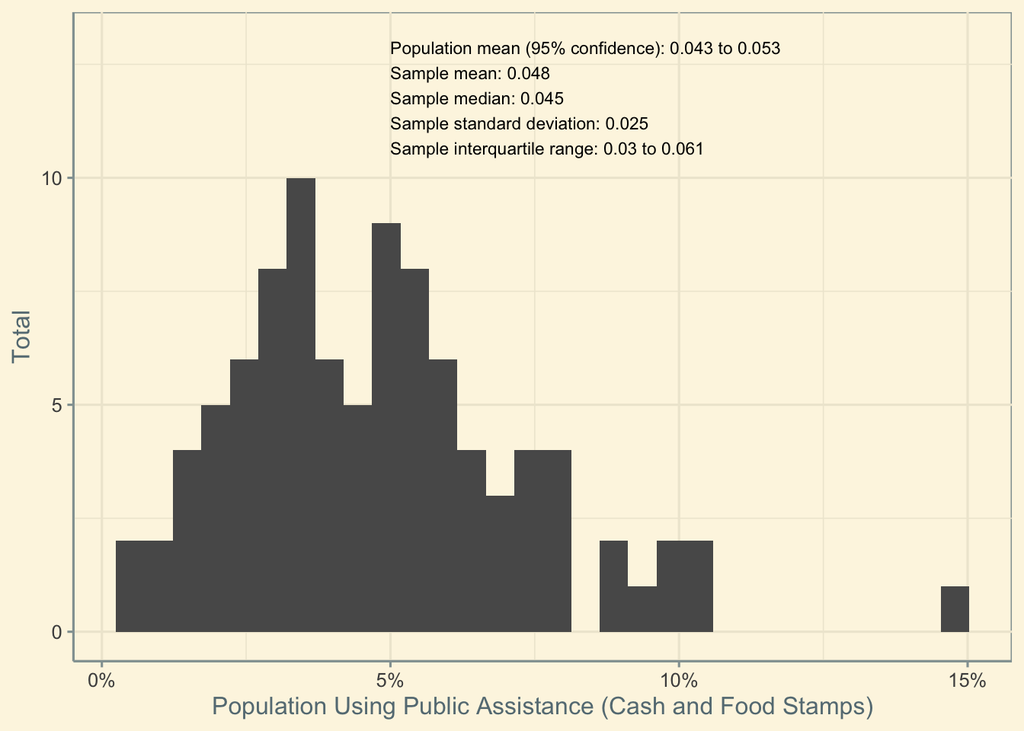

```r
hist7+
  theme_solarized() +
  scale_x_continuous(name = "Population Using Public Assistance (Cash and Food Stamps)",
                     breaks = seq(0.0, 0.5, by = .05),
                     labels = paste(seq(0, 50, by = 5), "%", sep = "")) +
  scale_y_continuous(name = "Total") +
  annotate("text", x = .05, y = 13, size = 3,
           label = paste("Population mean (95% confidence):",
                         prettyNum(pop_mean7$conf.int[1], digits = 2),
                         "to",
                         prettyNum(pop_mean7$conf.int[2], digits = 2),

                         "\nSample mean:",
                         prettyNum(mean(cash_assist), digits = 2),
                         "\nSample median:",
                         prettyNum(median(cash_assist), digits = 2),
                         "\nSample standard deviation:",
                         prettyNum(sd(cash_assist), digits = 2),
                         "\nSample interquartile range:",
                         prettyNum(quantile(cash_assist)["25%"], digits = 2),
                         "to",
                         prettyNum(quantile(cash_assist)["75%"], digits = 2)),
           hjust = 0, vjust = 1)
```

### T-Test: High- School Graduates

**The California statewide high school graduation rate is 83%. High school graduation proportion is categorized as either meeting or exceeding this 83% threshold or being below.**

```r
meets_hs_grads <- t.test(majority_grads)
below_hs_grads <- t.test(!majority_grads)
```

```r
grads_shares <- tibble('High School Graduation Rate' = c("Meets Statewide Average",
                                    "Below Statewide Average"),
                     `Sample` =c(paste(prettyNum(meets_hs_grads$estimate*100,
                                         digits = 3), "%"),
                         paste(prettyNum(below_hs_grads$estimate*100,
                                         digits = 3), "%")),
                      `95-percent confidence interval` =
                        c(paste(prettyNum(meets_hs_grads$conf.int[1]*100,
                                          digits = 3), "% to ",
                                prettyNum(meets_hs_grads$conf.int[2]*100,
                                          digits = 3), "%"),
                         paste(prettyNum(below_hs_grads$conf.int[1]*100,
                                          digits = 3), "% to ",
                                prettyNum(below_hs_grads$conf.int[2]*100,
                                          digits = 3), "%")))
knitr::kable(grads_shares, caption = "Census Tracts in Jefferson Region")
```

Census Tracts in Jefferson Region

| High School Graduation Rate | Sample | 95-percent confidence interval |
| --- | --- | --- |
| Meets Statewide Average | 95.7 % | 91.6 % to 99.9 % |
| Below Statewide Average | 4.26 % | 0.0989 % to 8.41 % |

### T-Test: Some College or Associates

**The California statewide rate of population with some college or an associates degree is 29%. ‘Some college or associates’ proportion is categorized as either meeting or exceeding this 29% threshold or being below.**

```r
meets_college <- t.test(majority_college)
below_college <- t.test(!majority_college)
```

```r
college_shares <- tibble('Some College' = c("Meets Statewide Average",
                                    "Below Statewide Average"),
                     `Sample` =c(paste(prettyNum(meets_college$estimate*100,
                                         digits = 3), "%"),
                         paste(prettyNum(below_college$estimate*100,
                                         digits = 3), "%")),
                      `95-percent confidence interval` =
                        c(paste(prettyNum(meets_college$conf.int[1]*100,
                                          digits = 3), "% to ",
                                prettyNum(meets_college$conf.int[2]*100,
                                          digits = 3), "%"),
                         paste(prettyNum(below_college$conf.int[1]*100,
                                          digits = 3), "% to ",
                                prettyNum(below_college$conf.int[2]*100,
                                          digits = 3), "%")))
knitr::kable(college_shares, caption = "Census Tracts in Jefferson Region")
```

Census Tracts in Jefferson Region

| Some College | Sample | 95-percent confidence interval |
| --- | --- | --- |
| Meets Statewide Average | 59.6 % | 49.5 % to 69.7 % |
| Below Statewide Average | 40.4 % | 30.3 % to 50.5 % |

### T-Test: Bachelor’s Degree

```r
meets_bachelors <- t.test(majority_bachelors)
below_bachelors <- t.test(!majority_bachelors)
```

```r
bachelors_shares <- tibble('Bachelors Degree'  = c("Meets Statewide Average",
                                    "Below Statewide Average"),
                     `Sample` =c(paste(prettyNum(meets_bachelors$estimate*100,
                                         digits = 3), "%"),
                         paste(prettyNum(below_bachelors$estimate*100,
                                         digits = 3), "%")),
                      `95-percent confidence interval` =
                        c(paste(prettyNum(meets_bachelors$conf.int[1]*100,
                                          digits = 3), "% to ",
                                prettyNum(meets_bachelors$conf.int[2]*100,
                                          digits = 3), "%"),
                         paste(prettyNum(below_bachelors$conf.int[1]*100,
                                          digits = 3), "% to ",
                                prettyNum(below_bachelors$conf.int[2]*100,
                                          digits = 3), "%")))
knitr::kable(bachelors_shares, caption = "Census Tracts in Jefferson Region")
```

Census Tracts in Jefferson Region

| Bachelors Degree | Sample | 95-percent confidence interval |
| --- | --- | --- |
| Meets Statewide Average | 2.13 % | -0.844 % to 5.1 % |
| Below Statewide Average | 97.9 % | 94.9 % to 101 % |

```r
write_csv(Jefferson_tract_data, "jeffersontractdata2018.csv")
```